# Session 1 — Rappels mathématiques et approfondissement des méthodes de classification

Maxence Cabiddu maxence.cabiddu@gmail.com

# 1. Rappels mathématiques fondamentaux

## 1.1 Algèbre linéaire

**Concepts clés :**

- **Vecteurs** :
  - Liste ordonnée de nombres.
  - Exemple : caractéristiques d'un échantillon.

  Exemple de vecteur $v$ :

  $$ v = \begin{bmatrix} 170 \\ 65 \end{bmatrix} $$

  où :
  - 170 = taille en cm,
  - 65 = poids en kg.
- **Matrices** :
  - Tableau rectangulaire de vecteurs.
  - Plusieurs échantillons organisés en lignes/colonnes.

  Exemple de matrice $A$ représentant trois individus :

  $$ A = \begin{bmatrix} 170 & 65 \\ 160 & 60 \\ 180 & 75 \end{bmatrix} $$

  Chaque ligne correspond à un individu : $(\text{taille}, \text{poids})$.

**Opérations fondamentales :**

- **Produit scalaire (dot product)** :

  Combine deux vecteurs $v$ et $u$ en un seul nombre réel :

  $$ v \cdot u = \sum_{i=1}^n v_i u_i $$

  ➔ Cela mesure **à quel point deux vecteurs pointent dans la même direction**.  
  Si le produit est élevé, les vecteurs sont "alignés" ; s'il est nul, ils sont perpendiculaires.

  **Exemple :**

  Supposons deux individus décrits par (taille en cm, poids en kg) :
  - Individu A :

    $$ v = \begin{bmatrix} 170 \\ 65 \end{bmatrix} $$
  - Individu B :

    $$ u = \begin{bmatrix} 180 \\ 70 \end{bmatrix} $$

  Calcul du produit scalaire :

  $$ v \cdot u = (170 \times 180) + (65 \times 70) $$

  $$ v \cdot u = 30600 + 4550 = 35150 $$

  ➔ Le produit scalaire est élevé, ce qui signifie que **les vecteurs (caractéristiques)** sont **assez alignés** :  
  les deux individus sont **de taille et de poids relativement similaires**.

[figure not shown]

*Source : [math.libretexts.org – Illustration produit scalaire](https://math.libretexts.org)*

- **Norme** :

  Donne la **longueur** d'un vecteur $ v $, c’est-à-dire sa distance à l'origine :

  $$ \|v\| = \sqrt{\sum_{i=1}^n v_i^2} $$

  ➔ Permet de calculer des distances ou de comparer la taille de différents vecteurs.

[figure not shown]

  *Source : [nagwa.com – Illustration vecteur 1](https://nagwa.com)* *Source : [blaisepascal.fr – Illustration vecteur 2](https://blaisepascal.fr)*

  **Exemple :**

  $$ v = (3, 4) $$ $$ \|v\| = \sqrt{3^2 + 4^2} = \sqrt{25} = 5 $$
- **Multiplication matrice-vecteur** :

  Multiplie une matrice $ A $ par un vecteur $ x $ :

  $$ y = A \times x $$

  ➔ Permet d'**appliquer une transformation linéaire** à un vecteur : rotation, changement d'échelle, etc.

  **Exemple :**

  $$ A = \begin{bmatrix} 1 & 2 \\ 3 & 4 \end{bmatrix} ,\quad x = \begin{bmatrix} 5 \\ 6 \end{bmatrix} $$ $$ y = \begin{bmatrix} 1\times5 + 2\times6 \\ 3\times5 + 4\times6 \end{bmatrix} = \begin{bmatrix} 17 \\ 39 \end{bmatrix} $$
- **Multiplication matrice-matrice** :

  Multiplie deux matrices $ A $ (de taille $ m \times n $) et $ B $ (de taille $ n \times p $) :

  $$ C = A \times B $$ Chaque élément $ C_{ij} $ est calculé par :

  $$ C_{ij} = \sum_{k=1}^n A_{ik} B_{kj} $$

  ➔ Permet de **combiner plusieurs transformations** successives en une seule opération.

  **Exemple :**

  $$ A = \begin{bmatrix} 1 & 2 \\ 3 & 4 \end{bmatrix} ,\quad B = \begin{bmatrix} 7 & 8 \\ 9 & 10 \end{bmatrix} $$ $$ C = A \times B = \begin{bmatrix} 1\times7 + 2\times9 & 1\times8 + 2\times10 \\ 3\times7 + 4\times9 & 3\times8 + 4\times10 \end{bmatrix} = \begin{bmatrix} 25 & 28 \\ 57 & 64 \end{bmatrix} $$

## Illustration de la multiplication de matrices

[figure not shown]

*Source : [Tutorat Homes – Multiplication de matrice](https://tutorathomes.com/)*

```python
# Module interactif pour tester les opérations de base (sur des individus : taille, poids)

import numpy as np

# Définir un vecteur v (exemple : caractéristiques d'une personne : taille en cm, poids en kg)
v = np.array([170, 65])  # Personne A : 170 cm, 65 kg

# Définir un autre vecteur u
u = np.array([180, 70])  # Personne B : 180 cm, 70 kg

# Définir une matrice A (ex : 3 personnes différentes)
A = np.array([
    [170, 65],  # Personne 1
    [160, 60],  # Personne 2
    [180, 75]   # Personne 3
])

# Définir un vecteur x pour tester la multiplication matrice-vecteur
x = np.array([1, 2])

# Définir une autre matrice B pour tester la multiplication matrice-matrice
B = np.array([
    [7, 8],
    [9, 10]
])

# ----------------------
# Calculs
# ----------------------

print("Vecteur v (Personne A) :", v)
print("Vecteur u (Personne B) :", u)
print("Produit scalaire v . u :", np.dot(v, u))
print("Norme de v (longueur du vecteur v) :", np.linalg.norm(v))

print("\nMatrice A (3 personnes) :\n", A)
print("Dimension de A: ", A.shape)
print("Vecteur x :", x)
print("Multiplication matrice-vecteur A @ x :\n", A @ x)

print("\nMatrice B :\n", B)
print("Dimension de B: ", B.shape)
print("Multiplication matrice-matrice A[:2, :] @ B :\n", A @ B)  # attention : tailles compatibles (3,2 @ 2,2)
# A @ B equivalent A.dot(B)
A.dot(B)
```

```
Vecteur v (Personne A) : [170  65]
Vecteur u (Personne B) : [180  70]
Produit scalaire v . u : 35150
Norme de v (longueur du vecteur v) : 182.00274723201295

Matrice A (3 personnes) :
 [[170  65]
 [160  60]
 [180  75]]
Dimension de A:  (3, 2)
Vecteur x : [1 2]
Multiplication matrice-vecteur A @ x :
 [300 280 330]

Matrice B :
 [[ 7  8]
 [ 9 10]]
Dimension de B:  (2, 2)
Multiplication matrice-matrice A[:2, :] @ B :
 [[1775 2010]
 [1660 1880]
 [1935 2190]]
```

```
array([[1775, 2010],
       [1660, 1880],
       [1935, 2190]])
```

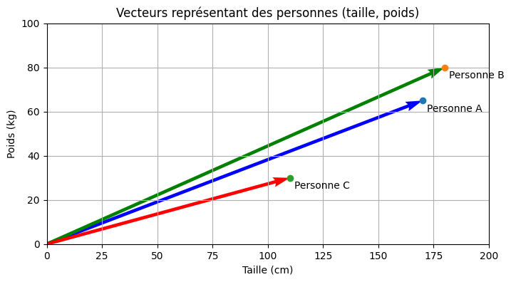

```python
# Affichage des vecteurs représentant les personnes dans un repère, depuis (0, 0)

import numpy as np
import matplotlib.pyplot as plt

# Définir les vecteurs des personnes (taille en cm, poids en kg)
personnes = np.array([
    [170, 65],  # Personne A
    [180, 80],  # Personne B
    [110, 30]   # Personne C
])

noms = ['Personne A', 'Personne B', 'Personne C']

# Création du graphique
plt.figure(figsize=(8, 6))

# Tracer les vecteurs depuis l'origine (0, 0)
origin = np.zeros((3, 2))
plt.quiver(
    origin[:, 0], origin[:, 1],
    personnes[:, 0], personnes[:, 1],
    angles='xy', scale_units='xy', scale=1, color=['blue', 'green', 'red']
)

# Ajouter les extrémités
for i in range(len(personnes)):
    plt.plot(personnes[i, 0], personnes[i, 1], 'o')
    plt.text(personnes[i, 0] + 2, personnes[i, 1] - 5, noms[i])

# Configurer les axes pour démarrer à 0
plt.xlim(0, 200)
plt.ylim(0, 100)

plt.xlabel('Taille (cm)')
plt.ylabel('Poids (kg)')
plt.title('Vecteurs représentant des personnes (taille, poids)')
plt.grid()
plt.gca().set_aspect('equal')  # Échelle équivalente pour X et Y

plt.show()
```

## 1.2 Probabilités et statistiques

**Concepts clés :**

- **Variable aléatoire** :
  - Discrète : prend un nombre fini ou dénombrable de valeurs (ex : lancer un dé → {1,2,3,4,5,6})
  - Continue : peut prendre toutes les valeurs d'un intervalle (ex : température mesurée en degrés)
- **Espérance** (valeur moyenne théorique) :

  $$ \mathbb{E}[X] = \sum_x x \, \mathbb{P}(X=x) \quad \text{(discret)} $$

  ou

  $$ \mathbb{E}[X] = \int_{-\infty}^{+\infty} x\, f(x) \, dx \quad \text{(continu)} $$

  ➔ L'espérance donne **la moyenne attendue** d'une variable aléatoire si l'on répète l'expérience à l'infini.

  **Exemple discret** : lancer de dé équilibré

  $$ \mathbb{E}[X] = \frac{1+2+3+4+5+6}{6} = 3.5 $$
- **Variance** (dispersion autour de l'espérance) :

  $$ \mathrm{Var}(X) = \mathbb{E}[(X - \mathbb{E}[X])^2] $$

  ➔ La variance mesure **l'écart moyen au carré** entre les réalisations et la moyenne attendue.  
  ➔ Plus la variance est grande, plus les valeurs de $X$ sont **dispersées** autour de $\mathbb{E}[X]$.

  **Intuition** :
  - Faible variance : les tirages sont proches de la moyenne.
  - Forte variance : les tirages peuvent être très éloignés de la moyenne.

[figure not shown]

*Source : [Wikimedia - Illustration variance](https://wikimedia.org/)*

**Exemple rapide** :

Si $X$ est un dé équilibré :

$$ \mathrm{Var}(X) = \mathbb{E}[X^2] - (\mathbb{E}[X])^2 $$ où $$ \mathbb{E}[X^2] = \frac{1^2+2^2+3^2+4^2+5^2+6^2}{6} = \frac{91}{6} $$

donc

$$ \mathrm{Var}(X) = \frac{91}{6} - (3.5)^2 \approx 2.916 $$

## 1.3 Optimisation

**Concepts clés :**

- **Fonction de coût** :
  - Mesure **l'erreur** entre les prédictions du modèle et les vraies valeurs.
  - Objectif : **minimiser** cette fonction.
- **Convexité** :
  - Une fonction est convexe si **n'importe quel segment entre deux points de la courbe reste au-dessus de la courbe**.
  - Convexité $\Rightarrow$ **minimum global unique**.
- **Descente de gradient** :

  $$ \theta \leftarrow \theta - \eta \nabla_\theta J(\theta) $$
  - À chaque étape, on ajuste les paramètres $\theta$ **dans la direction qui réduit** la fonction de coût $J(\theta)$.
  - $\eta$ est le **taux d'apprentissage** (learning rate).

**Exemple simple :**

Minimiser :

$$ f(x) = (x-3)^2 $$

- La fonction $f(x)$ est convexe (parabole tournée vers le haut).
- Son minimum global est atteint pour $x=3$.

# 2. Régression logistique

## 2.1 Modèle et fonction de coût

**Modèle binaire (classification à 2 classes)** :

On cherche à prédire une probabilité $\hat{y}$ que l'échantillon appartienne à la classe 1 :

$$ \hat{y} = \sigma(w^T x + b) $$

où :

- $w$ est le vecteur de poids,
- $x$ est le vecteur d'entrée,
- $b$ est le biais,
- $\sigma(z)$ est la **fonction sigmoïde** :

$$ \sigma(z) = \frac{1}{1+e^{-z}} $$

➔ La sigmoïde "écrase" n'importe quel nombre réel entre $0$ et $1$ : elle transforme une somme pondérée de variables en **probabilité**.

**Visualisation de la fonction sigmoïde :**

[figure not shown]

*Source : [Wikipedia – Logistic Function](https://en.wikipedia.org/wiki/Logistic_function)*

- L'axe horizontal montre $z$ (le score linéaire).
- L'axe vertical montre $\sigma(z)$ (la probabilité prédite).

On voit que :

- Quand $z$ est très grand, $\sigma(z) \approx 1$,
- Quand $z$ est très petit, $\sigma(z) \approx 0$,
- Et autour de $z=0$, la courbe est **la plus raide**.

**Fonction de coût (log-loss)** :

On mesure **l'écart entre les prédictions $\hat{y}^{(i)}$ et les vraies étiquettes $y^{(i)}$** avec une fonction appelée **log-loss** ou **cross-entropy binaire** :

$$ J(w,b) = -\frac{1}{N} \sum_{i=1}^{N} \left[ y^{(i)} \log(\hat{y}^{(i)}) + (1-y^{(i)}) \log(1-\hat{y}^{(i)}) \right] $$

**Intuition** :

- Si la prédiction est correcte ($\hat{y} \approx y$), la perte est faible.
- Si la prédiction est fausse ($\hat{y}$ est loin de $y$), la perte est forte.

➔ L'objectif est de **minimiser cette fonction de coût**.

**Remarque**

Quand on calcule la log-loss pour un seul exemple :

- Si la vraie étiquette $y = 1$, la loss devient :

  $$ -\log(\hat{y}) $$
- Si la vraie étiquette $y = 0$, la loss devient :

  $$ -\log(1-\hat{y}) $$

➔ La log-loss **s'adapte automatiquement** selon que l'exemple appartient à la classe $1$ ou la classe $0$.

**Exemple rapide :**

- Vraie étiquette : $y=1$
- Prédiction : $\hat{y}=0.9$

La contribution à la fonction de coût est :

$$ -\left( 1 \times \log(0.9) + (1-1) \times \log(1-0.9) \right) = -\log(0.9) \approx 0.105 $$

(valeur faible = bonne prédiction)

**Extension multiclasses :**

Quand il y a plus de deux classes :

- On utilise **softmax** à la place de la sigmoïde :

$$ \text{softmax}(z_i) = \frac{e^{z_i}}{\sum_{j} e^{z_j}} $$

- Chaque sortie représente une **probabilité par classe**. **Exemple rapide :**  
  Si un modèle produit les scores $(2.0,\ 1.0,\ 0.1)$, alors après softmax :

$$ \hat{y} \approx (0.66,\ 0.24,\ 0.10) $$

➔ Le modèle attribue 66% à la première classe, 24% à la deuxième, 10% à la troisième.

- La fonction de coût devient la **cross-entropy catégorique** :

$$ J = -\frac{1}{N} \sum_{i=1}^N \sum_{c=1}^C y_c^{(i)} \log(\hat{y}_c^{(i)}) $$

où :

- $C$ est le nombre de classes,
- $y_c^{(i)}$ est 1 si l'observation $i$ appartient à la classe $c$, sinon 0.

**Résumé visuel** :

| Cas | Activation | Coût utilisé |
| --- | --- | --- |
| Binaire (2 classes) | Sigmoïde | Log-loss |
| Multiclasses | Softmax | Cross-entropy catégorique |

```python
import numpy as np
import torch

scores = np.array([2.0, 1.0, 0.1])

softmax_class1 = np.exp(2.0) / np.sum(np.exp(scores))
print(softmax_class1)

torch.softmax(torch.tensor(scores), dim=0)
```

```
0.6590011388859679
```

```
tensor([0.6590, 0.2424, 0.0986], dtype=torch.float64)
```

### Pourquoi la fonction de coût doit être convexe

- Une fonction **convexe** a **un seul minimum global**.
- Cela garantit que **la descente de gradient** trouvera ce minimum sans être piégée dans un mauvais "creux".

[figure not shown]

*Source : [Wikipedia — Convex Function](https://en.wikipedia.org/wiki/Convex_function)*

- fonction **convexe** ➔ minimum global facile à trouver,

**Dans la régression logistique** :

- La log-loss est **convexe** par rapport à $w$ et $b$.
- C'est pour cela que l'optimisation par descente de gradient **fonctionne bien**.

### **Exemple : classification binaire avec régression logistique**

On considère un modèle de régression logistique simple avec :

- Vecteur de poids : $w = \begin{bmatrix} 2 \\ -1 \end{bmatrix}$
- Biais : $b = 0.5$

On veut prédire pour l’exemple suivant :

- Entrée $x = \begin{bmatrix} 1 \\ 3 \end{bmatrix}$
- Vraie étiquette $y = 0$

### Étape 1 : Calcul du score linéaire $z$

$$ z = w^T x + b = (2 \times 1) + (-1 \times 3) + 0.5 = 2 - 3 + 0.5 = -0.5 $$

### Étape 2 : Passage par la fonction sigmoïde

$$ \hat{y} = \sigma(z) = \frac{1}{1 + e^{-z}} = \frac{1}{1 + e^{0.5}} \approx \frac{1}{1 + 1.6487} \approx 0.3775 $$

➔ Le modèle prédit $\hat{y} \approx 0.3775$ (probabilité d'appartenir à la classe $1$).

### Étape 3 : Calcul de la log-loss pour cet exemple

La fonction de coût pour un seul exemple est :

$$ \text{log-loss} = -\left( y \log(\hat{y}) + (1-y) \log(1-\hat{y}) \right) $$

Ici, $y = 0$, donc :

$$ \text{log-loss} = -\log(1-\hat{y}) = -\log(1-0.3775) = -\log(0.6225) $$

$$ \text{log-loss} \approx -(-0.4737) = 0.4737 $$

### Résumé

| Étape | Résultat |
| --- | --- |
| Score linéaire $z$ | $-0.5$ |
| Probabilité prédite $\hat{y}$ | $0.3775$ |
| Fonction de coût (log-loss) | $0.4737$ |

**Interprétation** :

- Le modèle donne 37% de chances que $x$ soit de classe $1$.
- Comme la vraie classe est $0$, la perte est **modérée** ($\approx 0.47$).

## 2.2 Dérivées, dérivées partielles et gradient

### Pourquoi utiliser des dérivées ?

Notre objectif est de **minimiser** la fonction de coût $J(w,b)$.

- **Minimiser**, c'est trouver là où la fonction atteint son **point le plus bas**.
- En mathématiques, pour savoir comment une fonction change, on utilise **la dérivée**.

La **dérivée** d'une fonction $f(x)$ au point $x$ mesure :

> "À quelle vitesse (et dans quelle direction) $f(x)$ change si je fais **un tout petit pas** autour de $x$."

**Définition formelle** (limite) :

$$ f'(x) = \lim_{h \to 0} \frac{f(x+h) - f(x)}{h} $$

- **$h$** est un tout petit déplacement.
- Le rapport mesure **le taux de variation**.

[figure not shown]

  *Source : [schoolmouv.fr – Illustration dérivée](https://www.schoolmouv.fr)*

**En optimisation** :

- Si la dérivée est **positive**, la fonction monte → on veut aller **vers la gauche** (réduire $x$).
- Si la dérivée est **négative**, la fonction descend → on veut aller **vers la droite** (augmenter $x$).

**Descente de gradient** = **aller dans la direction opposée à la dérivée** pour diminuer la fonction.

### Dérivées partielles

Quand la fonction dépend de **plusieurs variables** (par exemple tous les poids $w_1, w_2, \dots, w_n$),  
on parle de **dérivées partielles**.

**Dérivée partielle** = dérivée **par rapport à une seule variable**, **en laissant les autres constantes**.

Notation pour $J(w_1, w_2, w_3)$ :

- $\frac{\partial J}{\partial w_1}$ : variation de $J$ quand **seul** $w_1$ change,
- $\frac{\partial J}{\partial w_2}$ : variation de $J$ quand **seul** $w_2$ change,
- etc.

**Pourquoi ?**

- Cela nous permet de savoir **comment ajuster chaque poids individuellement** pour réduire la perte.

### Gradient

Le **gradient** est simplement **le vecteur de toutes les dérivées partielles** :

$$ \nabla_w J = \begin{bmatrix} \frac{\partial J}{\partial w_1} \\ \frac{\partial J}{\partial w_2} \\ \vdots \\ \frac{\partial J}{\partial w_n} \end{bmatrix} $$

- Le gradient indique **la direction dans laquelle $J$ augmente le plus vite**.
- En descente de gradient, **on suit la direction opposée** pour **réduire** $J$.

**Métaphore simple** :

> Imagine que tu es dans une vallée en montagne avec les yeux fermés.  
> Le **gradient** est le **vecteur qui te dit dans quelle direction la pente monte le plus fort**.  
> Pour descendre, tu fais l'inverse.

### Résumé visuel :

| Concept | Explication simple |
| --- | --- |
| Dérivée | Variation locale d'une fonction par rapport à son entrée |
| Dérivée partielle | Variation locale par rapport à **une seule variable** |
| Gradient | Ensemble des dérivées partielles = **direction de la plus forte montée** |
| Descente de gradient | Faire des petits pas dans la direction opposée pour **réduire la perte** |

### **Exemple : Calcul des gradients pour un seul exemple de régression logistique**

### Rappel

- Poids : $$ w = \begin{bmatrix} 2 \\ -1 \end{bmatrix} $$
- Biais : $$ b = 0.5 $$
- Entrée : $$ x = \begin{bmatrix} 1 \\ 3 \end{bmatrix} $$
- Vraie étiquette : $$ y = 0 $$

### Étape 1 : Calcul du score linéaire $z$

Déjà fait précédemment :

$$ z = w^T x + b = -0.5 $$

### Étape 2 : Calcul de la probabilité prédite $\hat{y}$

Déjà fait précédemment :

$$ \hat{y} = \sigma(z) \approx 0.3775 $$

### Étape 3 : Calcul de l'erreur $(\hat{y} - y)$

$$ \hat{y} - y = 0.3775 - 0 = 0.3775 $$

### Étape 4 : Calcul du gradient par rapport à $w$

La formule pour un seul exemple est :

$$ \nabla_w J = (\hat{y} - y) x $$

Calcul :

$$ \nabla_w J = 0.3775 \times \begin{bmatrix} 1 \\ 3 \end{bmatrix} = \begin{bmatrix} 0.3775 \\ 1.1325 \end{bmatrix} $$

### Étape 5 : Calcul du gradient par rapport à $b$

La formule est :

$$ \partial_b J = (\hat{y} - y) $$

Donc :

$$ \partial_b J = 0.3775 $$

### Résumé des gradients

| Élément | Valeur |
| --- | --- |
| $\nabla_w J$ | $\begin{bmatrix} 0.3775 \\ 1.1325 \end{bmatrix}$ |
| $\partial_b J$ | $0.3775$ |

### Étape 6 : Mise à jour des paramètres (si learning rate $\eta = 0.1$)

- Mise à jour de $w$ :

  $$ w \leftarrow w - \eta \nabla_w J $$

  Calcul :

  $$ w = \begin{bmatrix} 2 \\ -1 \end{bmatrix} - 0.1 \times \begin{bmatrix} 0.3775 \\ 1.1325 \end{bmatrix} = \begin{bmatrix} 2 - 0.03775 \\ -1 - 0.11325 \end{bmatrix} = \begin{bmatrix} 1.96225 \\ -1.11325 \end{bmatrix} $$
- Mise à jour de $b$ :

  $$ b \leftarrow b - \eta \partial_b J $$

  Calcul :

  $$ b = 0.5 - 0.1 \times 0.3775 = 0.5 - 0.03775 = 0.46225 $$

### Résumé après mise à jour

| Élément | Nouvelle valeur |
| --- | --- |
| $w$ | $\begin{bmatrix} 1.96225 \\ -1.11325 \end{bmatrix}$ |
| $b$ | $0.46225$ |

### Interprétation

Après une itération de descente de gradient :

- Les poids $w$ et le biais $b$ **ont été corrigés**,
- Le modèle **va mieux prédire** l'étiquette $y=0$ pour cet exemple particulier.

## 2.3 Impact du learning rate

### Qu'est-ce que le learning rate ?

- Le **learning rate** ($\eta$) contrôle **la taille des pas** que l'on fait à chaque mise à jour des paramètres.
- Il joue un rôle **crucial** dans l'efficacité et la stabilité de l'apprentissage.

### Effets d'un learning rate mal choisi

- **Learning rate trop petit** :
  - Les mises à jour sont **très lentes**.
  - L'optimisation peut mettre **beaucoup de temps** à converger.
- **Learning rate trop grand** :
  - Le modèle peut **osciller** autour du minimum sans jamais s'en approcher.
  - Peut même **diverger**, c'est-à-dire que la perte augmente au lieu de diminuer.

### Illustration schématique

| Learning rate | Comportement |
| --- | --- |
| Petit $\eta$ | Convergence lente |
| Bon $\eta$ | Convergence rapide et stable |
| Grand $\eta$ | Divergences, oscillations |

### Recommandation pratique

- Toujours **tester plusieurs valeurs** de learning rate (ex : $0.001$, $0.01$, $0.1$, $1.0$).
- Observer l'évolution de la **fonction de coût** au cours des itérations.
- Éventuellement utiliser des méthodes de réglage automatique (scheduler, annealing).

## 2.4 Standardisation des données

### Pourquoi standardiser les données ?

- La régression logistique repose sur l'optimisation du produit $w^T x$.
- Si certaines features ont des valeurs beaucoup plus grandes que d'autres, elles peuvent **dominer l'apprentissage**.
- Cela peut rendre la convergence **plus difficile** et **plus lente**.

### Qu'est-ce que standardiser ?

Standardiser consiste à transformer chaque feature $x_j$ selon la formule :

$$ x_j' = \frac{x_j - \mu_j}{\sigma_j} $$

où :

- $\mu_j$ est la **moyenne** de la feature $x_j$ sur le dataset,
- $\sigma_j$ est **l'écart-type** de la feature $x_j$.

Après standardisation :

- Chaque feature a une moyenne $0$ et un écart-type $1$.

#### Normalization

[figure not shown]

*Source : [Normalisation des données](https://pantelis.github.io/cs677/docs/common/lectures/optimization/whitening/)*

### Effets positifs de la standardisation

- Facilite **la descente de gradient** (les courbes de coût sont plus "circulaires" au lieu d'être allongées).
- Permet au modèle d'**apprendre plus rapidement**.
- Rend **l'interprétation** des poids plus cohérente.

### Quand est-ce indispensable ?

- Lorsque les features sont sur **des échelles différentes** (ex : taille en cm, poids en kg, revenu en euros).
- En pratique, il est souvent **préférable de standardiser systématiquement** pour les modèles linéaires.

### Remarque

- Si une régularisation est utilisée (comme L2), la standardisation est **encore plus importante** pour éviter un biais artificiel dû à la différence d'échelle des features.

### Exemple pratique

Utilisation classique avec `scikit-learn` :

```
from sklearn.preprocessing import StandardScaler

scaler = StandardScaler()
X_scaled = scaler.fit_transform(X)
```

## 2.5 Régularisation (L2)

### Pourquoi ajouter de la régularisation ?

- Quand le modèle est trop **complexe** (beaucoup de features), il peut **sur-apprendre** (overfitting) les détails du jeu de données.
- La **régularisation** pénalise les poids trop grands pour **forcer le modèle à rester simple**.

### Régularisation L2 (Ridge)

La régularisation L2 ajoute un terme de pénalisation à la fonction de coût :

$$ J_{\text{total}}(w,b) = J(w,b) + \lambda \|w\|_2^2 $$

où :

- $J(w,b)$ est la fonction log-loss classique,
- $\|w\|_2^2 = \sum_j w_j^2$ est la norme $L2$ au carré (la somme des carrés des poids),
- $\lambda$ est un hyperparamètre qui contrôle l'intensité de la pénalisation.

### Effet de la régularisation

- Encourage les **petits poids** $w_j$ (proches de zéro).
- Réduit le **risque de sur-apprentissage**.
- Améliore parfois la **généralisation** du modèle sur de nouvelles données.

### Formules de gradient modifiées

- Pour les poids $w$ :

  $$ \nabla_w J_{\text{total}} = \nabla_w J + 2\lambda w $$
- Le gradient par rapport au biais $b$ **ne change pas** car on ne pénalise pas le biais.

### Recommandation pratique

- Utiliser un $\lambda$ modéré au début (ex : $0.01$, $0.1$).
- Régler $\lambda$ par validation croisée pour trouver le meilleur compromis entre biais et variance.

### Exemple pratique avec `scikit-learn`

La régularisation est gérée automatiquement dans `LogisticRegression` :

```
from sklearn.linear_model import LogisticRegression

# C est l'inverse de la régularisation (C = 1 / lambda)
model = LogisticRegression(C=1.0, penalty='l2')
model.fit(X_train, y_train)
```